# Analysis for Hoecker and Higuera 2018:

## Setup

### Load the requisite packages

```r
library(tidyverse) # For data manipulation and plotting
library(zoo) # For rolling statistics
library(Hmisc) # For correlation statistics
library(knitr) # For formatting this file
```

### Load data from Rdata file

Specify location of .Rdata file in repository on your machine.

```r
load("/Users/tylerhoecker/GitHub/nowitna/data/complete_data.RData")
```

To load and/or compile proxies individually, run “load_indv_data.R” before proceeding.

### Visualize all proxies

#### Chronological data

Age-depth models were built in Bacon v2.2 (http://www.chrono.qub.ac.uk/blaauw/bacon.html), using the parameters described in the text (Table 2).

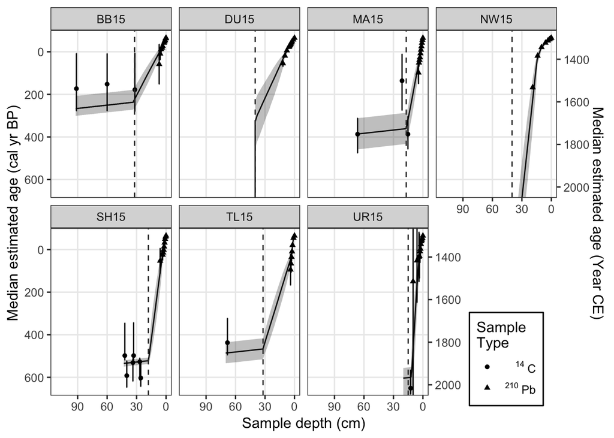

#### Charcoal data

Lake-specific CHAR records (black line), inferred fire events (black dots), and theshold used to define events (grey line). Processed in CharAnalysis (https://github.com/phiguera/CharAnalysis), using the parameters described in the text (Table 2).

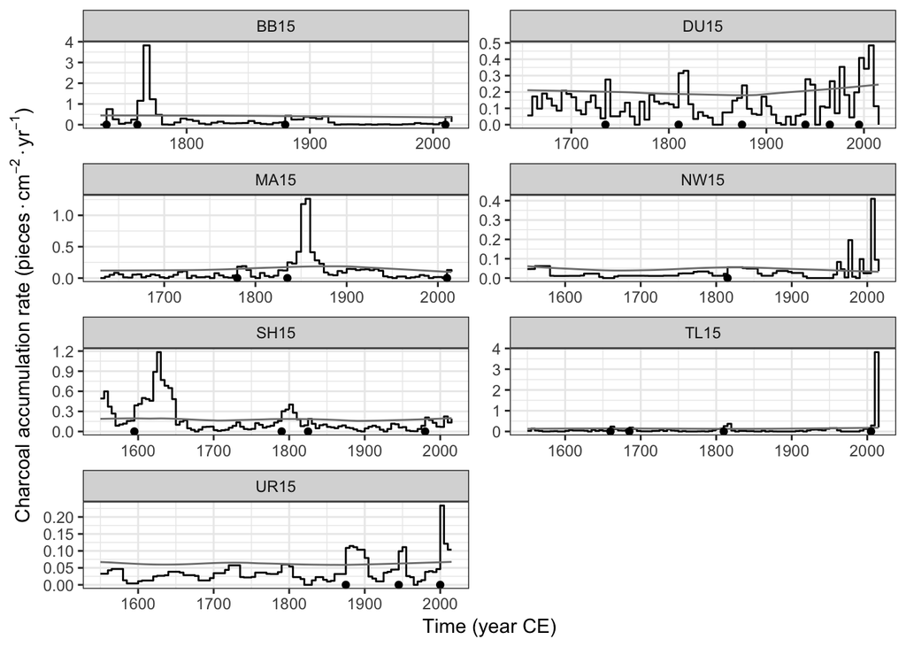

Composite biomass burning record from individual records (without peak analysis or interpolation using method in Kelly et al. 2013 (doi: 10.1073/pnas.1305069110). The method estimates the parameters of a zero-inflated log-normal (ZIL) distribution of pooled charcoal counts in continuous moving windows of a user-defined width. In this analysis, 5-year and 50-year window widths are used (2.5 and 25 half-kernel widths, respectively.

This portion of the analysis is relegated to a separate R script for clarity of the workflow. Window widths and other parameters can be manipulated within the ‘analysis_composite.r’ script.

Plot the composite record of biomass burning.

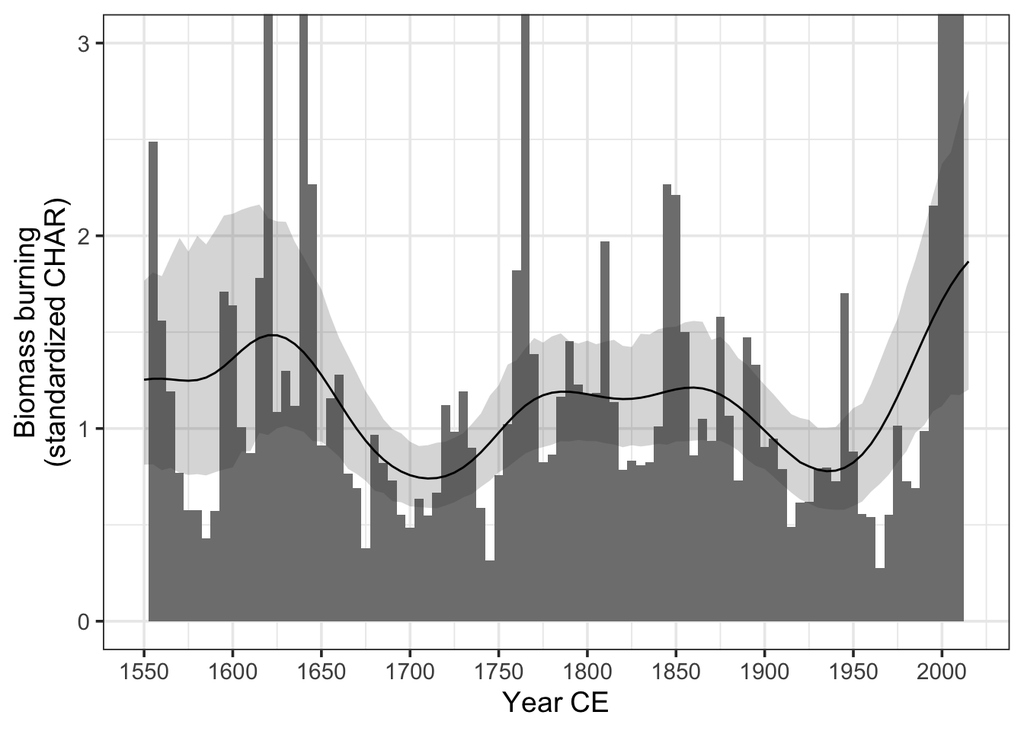

Plot time series of estimated pith dates by species.

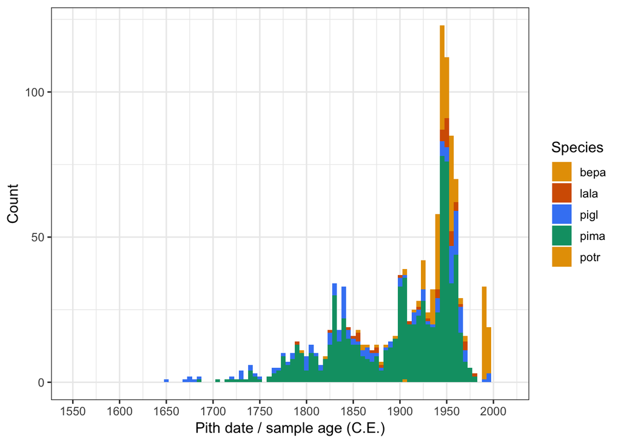

Plot standardized climate data.

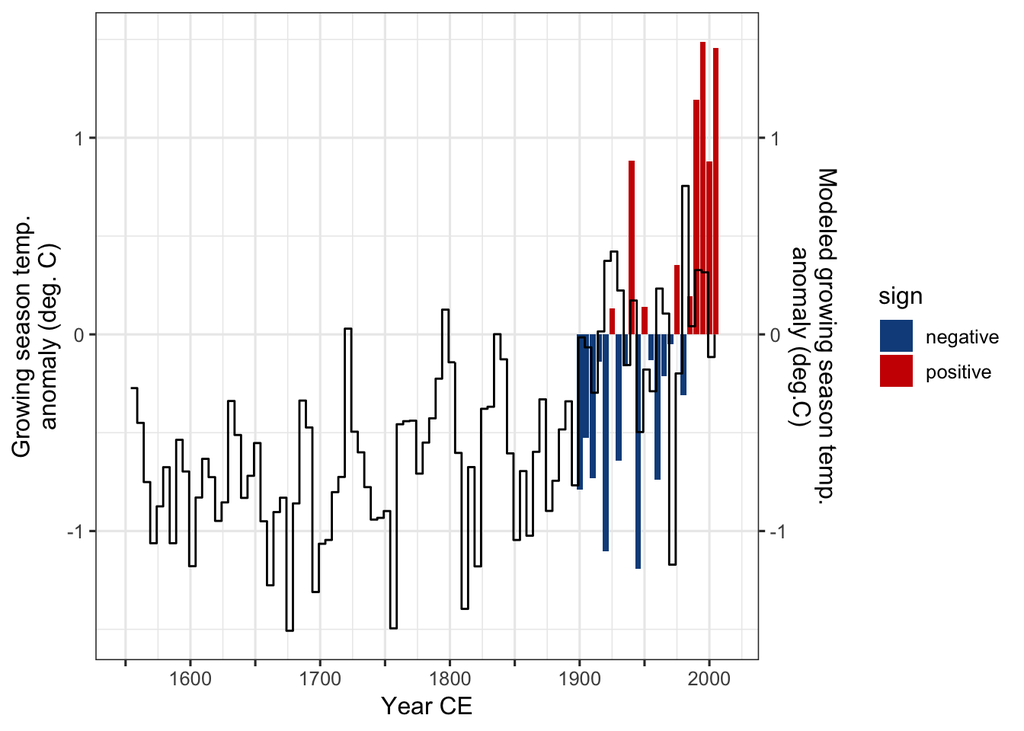

#### Summarize fire event metrics

Mean signal to noise indices of records during study period:

```r
kable(
  char.df %>%
    summarise(meanSNI = mean(SNI, na.rm = T)),
  caption = 'Mean SNI'
)
```

Mean SNI

| lake | meanSNI |
| --- | --- |
| BB15 | 9.8072 |
| DU15 | 3.3015 |
| MA15 | 8.6999 |
| NW15 | 6.0621 |
| SH15 | 11.1230 |
| TL15 | 14.1624 |
| UR15 | 4.7611 |

Study-wide mean fire return interval [FRI, years] (mean of all FRI pooled, rather than mean of means):

```r
FRI <- char.df %>%
  select(lake,peakYr,length) %>%
  filter(!is.na(peakYr)) %>%
  mutate(FRI =  (lead(peakYr, 1) - peakYr) * -1)

kable(
  FRI %>%
    ungroup(lake) %>%
    summarise(min = min(FRI, na.rm = T),
              max = max(FRI, na.rm = T),
              mean = mean(FRI, na.rm = T),
              median = median(FRI, na.rm = T),
              sd = sd(FRI, na.rm = T)),
  caption = 'Study-wide mean FRI'
)
```

Study-wide mean FRI

| min | max | mean | median | sd |
| --- | --- | --- | --- | --- |
| 25 | 195 | 90 | 67.5 | 59.82819 |

Individual mean FRI:

```r
kable(
  FRI %>%
  group_by(lake) %>%
  summarise(nFires = n(),
            mFRI = mean(FRI, na.rm = T),
            sdFRI = sd(FRI, na.rm = T),
            length = length[1],
            FF = nFires/length * 100) ,
  caption = 'Mean FRI'
)
```

Mean FRI

| lake | nFires | mFRI | sdFRI | length | FF |
| --- | --- | --- | --- | --- | --- |
| BB15 | 4 | 91.66667 | 57.95113 | 285 | 1.4035088 |
| DU15 | 6 | 52.00000 | 22.80351 | 360 | 1.6666667 |
| MA15 | 3 | 115.00000 | 84.85281 | 385 | 0.7792208 |
| NW15 | 1 | NaN | NA | 465 | 0.2150538 |
| SH15 | 4 | 128.33333 | 83.26664 | 465 | 0.8602151 |
| TL15 | 4 | 115.00000 | 85.44004 | 465 | 0.8602151 |
| UR15 | 3 | 62.50000 | 10.60660 | 465 | 0.6451613 |

Calculate the difference [years] between observed fire years within 1km of lakes and the most recent fire event detected in charcoal record

```r
char.df <- char.df %>%
  group_by(lake) %>%
  right_join(.,obs.1km, by = 'lake')

kable(
  char.df %>%
  group_by(lake) %>%
  summarise(observed = obsCE[1],
            lastPeak = max(peakYr, na.rm = T),
            difference = abs(obsCE[1] - max(peakYr, na.rm = T))),
  caption = 'Inferred vs. observed fire event timing.'
)
```

Inferred vs. observed fire event timing.

| lake | observed | lastPeak | difference |
| --- | --- | --- | --- |
| BB15 | 1991 | 2010 | 19 |
| DU15 | 1991 | 1995 | 4 |
| MA15 | 2013 | 2010 | 3 |
| NW15 | NA | 1815 | NA |
| SH15 | 1986 | 1980 | 6 |
| TL15 | 2013 | 2005 | 8 |
| UR15 | 1991 | 2000 | 9 |

## Analysis

#### Calculate proportion of sites burned through time, using 50-year windows in continuous 5-year time steps.

```r
window = 50 # years
timeStep = 5 # years

sitesByYear <- char.df %>% # Count the number of sites each year
  group_by(ageCE) %>%
  summarise(sites = n())

pctBurned <- char.df %>%
  filter(!is.na(peakYr)) %>%
  group_by(peakYr) %>%
  summarise(n.burned = n()) %>% # Sum number of sites burned each year
  rename(ageCE = peakYr) %>%
  full_join(sitesByYear,.) %>%
  mutate(n.burned = ifelse(!is.na(n.burned),n.burned,0)) %>%
  # Sum number of sites burned in 50-year windows centered at each timeStep
  mutate(win.total = rollapply(sites, window/timeStep, fill= NA,
                               FUN = mean, na.rm =T)) %>%
  mutate(win.burn = rollsum(n.burned, window/timeStep, fill= NA)) %>%
  mutate(win.pct = win.burn/win.total*100)

# Perform same calculation as above for modern period
modernTime <- seq(1950,2015,1)
modernSites = data.frame('ageCE' = modernTime, 'sites' = 6)

pctModern <- observed.df %>%
  filter(distance == 1) %>%
  group_by(ageCE) %>%
  summarise(n.burned = n()) %>%
  full_join(modernSites,.) %>%
  mutate(n.burned = ifelse(!is.na(n.burned),n.burned,0)) %>%
  # Sum number of sites burned in 50-year windows centered at each timeStep
  mutate(win.total = rollapply(sites, window, fill= NA,
                               FUN = mean, na.rm =T)) %>%
  mutate(win.burn = rollsum(n.burned, window, fill= NA)) %>%
  mutate(win.pct = win.burn/win.total*100)
```

Plot the result, a time series of FRI (grey squares), percent sites burned based on the charcoal record (black line), and percent sites burned based on observed fire data since 1950 (red line).

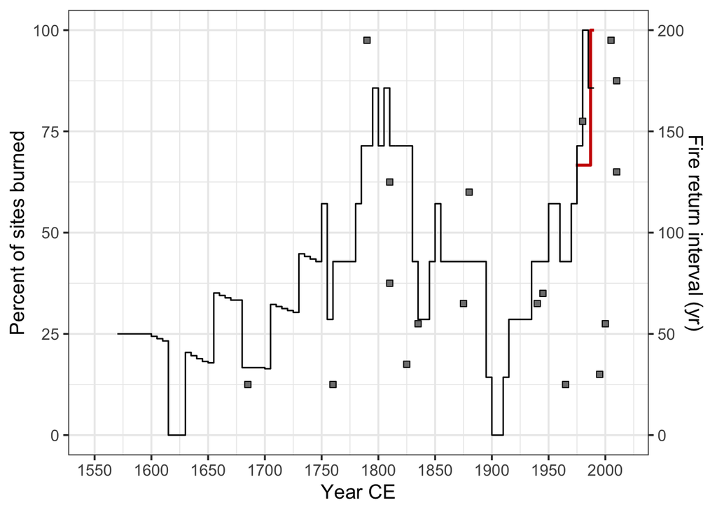

#### Compare proxies

```r
corr.1550_1895.df <- rcorr(as.matrix(combined.1550_1895.df), type="pearson")
corr.1900_2010.df <- rcorr(as.matrix(combined.1900_2010.df), type="pearson")
```

Correlation coefficients and p-values for period 1550-1895 CE.

R

|  | lowMean | highMean | win.pct | bin.temp | tree.count |
| --- | --- | --- | --- | --- | --- |
| lowMean | 1.0000000 | 0.4281591 | -0.0953683 | 0.0877347 | 0.5825862 |
| highMean | 0.4281591 | 1.0000000 | -0.1060908 | 0.0639381 | 0.1618890 |
| win.pct | -0.0953683 | -0.1060908 | 1.0000000 | 0.1504365 | 0.3575776 |
| bin.temp | 0.0877347 | 0.0639381 | 0.1504365 | 1.0000000 | 0.2877710 |
| tree.count | 0.5825862 | 0.1618890 | 0.3575776 | 0.2877710 | 1.0000000 |

P-Value

|  | lowMean | highMean | win.pct | bin.temp | tree.count |
| --- | --- | --- | --- | --- | --- |
| lowMean | NA | 0.0002177 | 0.4462324 | 0.4701601 | 0.0000517 |
| highMean | 0.0002177 | NA | 0.3965415 | 0.5989920 | 0.3057057 |
| win.pct | 0.4462324 | 0.3965415 | NA | 0.2279423 | 0.0200780 |
| bin.temp | 0.4701601 | 0.5989920 | 0.2279423 | NA | 0.0646032 |
| tree.count | 0.0000517 | 0.3057057 | 0.0200780 | 0.0646032 | NA |

Correlation coefficients and p-values for period 1900-2010 CE.

R

|  | ageCE | lowMean | highMean | win.pct | burned_ha | cru.precip | cru.temp | goa.temp | tree.count |
| --- | --- | --- | --- | --- | --- | --- | --- | --- | --- |
| ageCE | 1.0000000 | 0.9861653 | 0.5783290 | 0.7893522 | 0.4548989 | -0.0722158 | 0.6414746 | 0.2584726 | -0.7504677 |
| lowMean | 0.9861653 | 1.0000000 | 0.6345406 | 0.8453766 | 0.4571060 | 0.0052471 | 0.7105845 | 0.2839088 | -0.7075043 |
| highMean | 0.5783290 | 0.6345406 | 1.0000000 | -0.0302651 | 0.0471683 | 0.1107164 | 0.5147857 | 0.0196446 | 0.1039580 |
| win.pct | 0.7893522 | 0.8453766 | -0.0302651 | 1.0000000 | 0.1578672 | 0.2433069 | 0.3333201 | 0.4602002 | -0.4030919 |
| burned_ha | 0.4548989 | 0.4571060 | 0.0471683 | 0.1578672 | 1.0000000 | 0.0758537 | 0.2077244 | 0.1651040 | -0.4356725 |
| cru.precip | -0.0722158 | 0.0052471 | 0.1107164 | 0.2433069 | 0.0758537 | 1.0000000 | -0.0900626 | 0.4670097 | 0.5460071 |
| cru.temp | 0.6414746 | 0.7105845 | 0.5147857 | 0.3333201 | 0.2077244 | -0.0900626 | 1.0000000 | 0.2586108 | -0.4467697 |
| goa.temp | 0.2584726 | 0.2839088 | 0.0196446 | 0.4602002 | 0.1651040 | 0.4670097 | 0.2586108 | 1.0000000 | -0.2560514 |
| tree.count | -0.7504677 | -0.7075043 | 0.1039580 | -0.4030919 | -0.4356725 | 0.5460071 | -0.4467697 | -0.2560514 | 1.0000000 |

P-Value

|  | ageCE | lowMean | highMean | win.pct | burned_ha | cru.precip | cru.temp | goa.temp | tree.count |
| --- | --- | --- | --- | --- | --- | --- | --- | --- | --- |
| ageCE | NA | 0.0000000 | 0.0302743 | 0.0038639 | 0.1021927 | 0.8061980 | 0.0134100 | 0.3722596 | 0.0077923 |
| lowMean | 0.0000000 | NA | 0.0147860 | 0.0010474 | 0.1003301 | 0.9857967 | 0.0043946 | 0.3252679 | 0.0148747 |
| highMean | 0.0302743 | 0.0147860 | NA | 0.9296118 | 0.8727860 | 0.7063211 | 0.0596171 | 0.9468557 | 0.7609911 |
| win.pct | 0.0038639 | 0.0010474 | 0.9296118 | NA | 0.6429409 | 0.4709530 | 0.3164978 | 0.1543553 | 0.2480810 |
| burned_ha | 0.1021927 | 0.1003301 | 0.8727860 | 0.6429409 | NA | 0.7966172 | 0.4760924 | 0.5727125 | 0.1804341 |
| cru.precip | 0.8061980 | 0.9857967 | 0.7063211 | 0.4709530 | 0.7966172 | NA | 0.7594617 | 0.0922612 | 0.0822778 |
| cru.temp | 0.0134100 | 0.0043946 | 0.0596171 | 0.3164978 | 0.4760924 | 0.7594617 | NA | 0.3719949 | 0.1683244 |
| goa.temp | 0.3722596 | 0.3252679 | 0.9468557 | 0.1543553 | 0.5727125 | 0.0922612 | 0.3719949 | NA | 0.4472671 |
| tree.count | 0.0077923 | 0.0148747 | 0.7609911 | 0.2480810 | 0.1804341 | 0.0822778 | 0.1683244 | 0.4472671 | NA |

Plot scatterplots of linear relationships between temperature and fire proxies for the two periods.

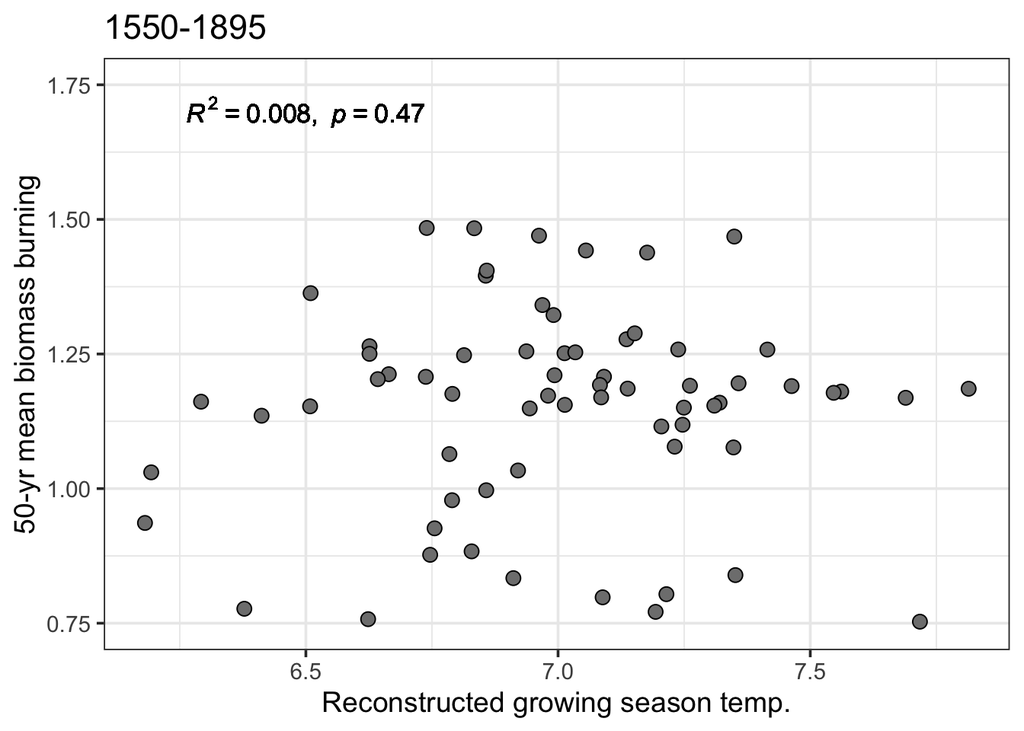

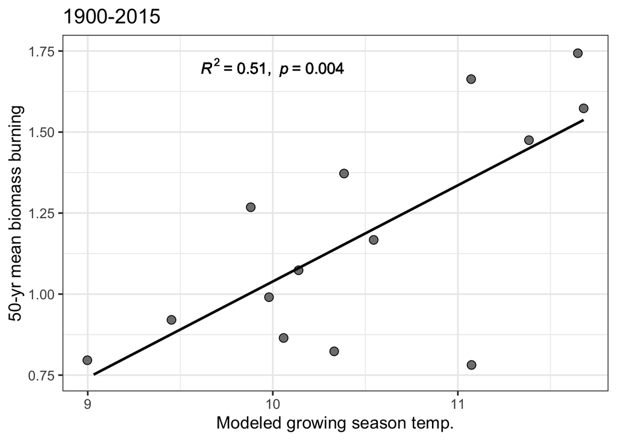